# BIOST 2041 Intro to Statistical Methods

R Learning Material 1– Getting Started

TA Crystal Zang

8/23/2020

# I. Basics

Here we are creating a variable and storing values in the variable. We say score A is a vector that contains 3 elements, and it’s a numeric variable. The first element of score A is 85, the second element is 89, and the third element is 92. We say the data type of scoreA and scoreB are numeric. Next, we create a student variable, where the student names, Alex, Jordan, and Ryan, are stored. The data type of student vector is character.

```r
#numeric
scoreA <- c()
scoreA <- c(85, 89, 92) #assign values to a variable

scoreA #print the variable
class(scoreA) #check the data type of the variable

scoreB <- c(75, 80, 95)
scoreB
class(scoreB)

scoreA[1] < scoreB[1]

1 > 2

scoreB > 80
pass <- scoreB > 80
class(pass)

#character
student <- c("Alex", "Jordan", "Ryan")
class(student)
```

[output not shown]

# II. Numeric Operations

```r
1 + 1

2 * 9

9/2

9^2

log(9)
```

[output not shown]

Now we know the basic numeric operations, we can perform these operations on the vectors we previously created.

```r
scoreA + scoreB

#calculate the sum of the elements in scoreA
sum(scoreA)

#find the number of elements in the vector scoreA
length(scoreA)

min(scoreA) #minimum

max(scoreA) #maximum

#calculate the mean of scoreA
mean(scoreA)
sum(scoreA)/length(scoreA)

#calculate the median of scoreA
median(scoreA)

#calculate standard deviation of scoreA
sd(scoreA)

#inter-quatile range of scoreA
IQR(scoreA)

#summary statistics of scoreA
summary(scoreA)
```

[output not shown]

## Question 1.

#### What’s the difference in the mean score A and mean score B

# III. R package Installation

**fivethirtyeight** R package hosts many datasets. You can find detailed information on these datasets here: https://fivethirtyeight-r.netlify.app/articles/fivethirtyeight.html.

We need to install an R package using the commend **install.packages()**. You only install package once. But everytime you open you R Markdown file, you have to read in the package using the commend **library()**. To find documentation of any R package use **?** with the name of the R package. For example **?fivethirtyeight**.

Packages you need to install: **fivethirtyeight**(dataset), **ggplot2**(visualization tool).

```r
#install from a published R package
#install.packages("fivethirtyeight")

#install from the repository to get the most recent updates
#install.packages('fivethirtyeightdata', repos ='https://fivethirtyeightdata.github.io/drat/',type = 'source')

library(fivethirtyeight)

#gives you the top rows of the dataset
head(bad_drivers)
```

```
##        state num_drivers perc_speeding perc_alcohol perc_not_distracted
## 1    Alabama        18.8            39           30                  96
## 2     Alaska        18.1            41           25                  90
## 3    Arizona        18.6            35           28                  84
## 4   Arkansas        22.4            18           26                  94
## 5 California        12.0            35           28                  91
## 6   Colorado        13.6            37           28                  79
##   perc_no_previous insurance_premiums losses
## 1               80             784.55 145.08
## 2               94            1053.48 133.93
## 3               96             899.47 110.35
## 4               95             827.34 142.39
## 5               89             878.41 165.63
## 6               95             835.50 139.91
```

```r
#data documentation including variable explainations
?bad_drivers

#View drug use dataset in a seperate tab
View(bad_drivers)
```

# IV. Dataframe

We will use **bad_drive** dataframe as an example. The raw data behind the story “Dear Mona, Which State Has The Worst Drivers?” https://fivethirtyeight.com/features/which-state-has-the-worst-drivers/

First, we want to know the dimension of the dataset. There are 51 U.S. states and 8 variables in the dataset. This dataset is in a “tidied” format, meaning that each row is an observation, preferable unique, and each column is variable. In this dataset, have have each row indicating a state.

```r
#find the number of row and column
dim(bad_drivers)
```

```
## [1] 51  8
```

We are interested in the percentage of drivers involved in fatal collisions who were speeding using the variable **perc_speeding** in the dataset. To extract a variable from a dataframe, we use **$**. An extracted variable is in a vector, similar to the scoreA variable that we showed before.

```r
bad_drivers$perc_speeding #print the variable
```

```
##  [1] 39 41 35 18 35 37 46 38 34 21 19 54 36 36 25 17 27 19 35 38 34 23 24 23 15
## [26] 43 39 13 37 35 16 19 32 39 23 28 32 33 50 34 38 31 21 40 43 30 19 42 34 36
## [51] 42
```

```r
length(bad_drivers$perc_speeding) #find the length of the variable
```

```
## [1] 51
```

```r
bad_drivers[1, ] #extract one row
```

```
##     state num_drivers perc_speeding perc_alcohol perc_not_distracted
## 1 Alabama        18.8            39           30                  96
##   perc_no_previous insurance_premiums losses
## 1               80             784.55 145.08
```

## Question 2.

#### Report the summary statistics (mean, standard deviation, IQR) of the percent speeding.

### Visualization

Here we are visualizing the distribution of the percentage of drivers involved in fatal collisions who were speeding among all 51 states.

#### 1. Visualization using Base R

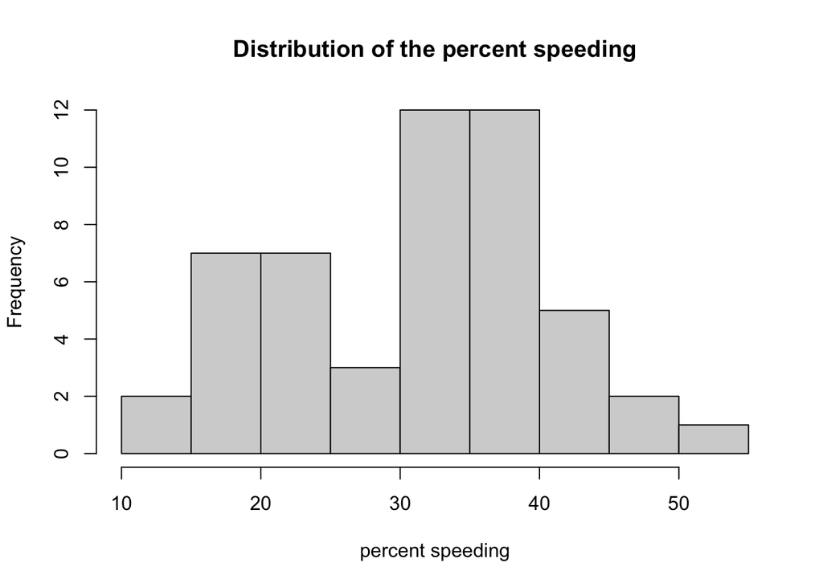

```r
#using base R to plot the histogram
hist(bad_drivers$perc_speeding,
     main = "Distribution of the percent speeding",  #title
     xlab = "percent speeding")  #title of x-axis
```

#### 2. Visualization using ggplot2

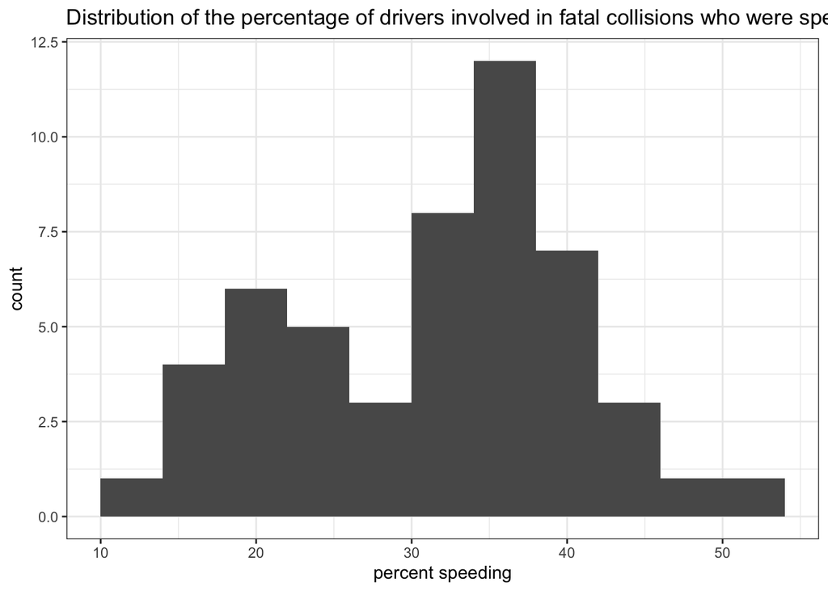

```r
#useing ggplot2 package to plot the histogram
#install.packages("ggplot2")

library(ggplot2)

ggplot(bad_drivers, aes(x = perc_speeding))+
  geom_histogram(binwidth = 4) +  #can manually change binwidth
  labs(title = "Distribution of the percentage of drivers involved in fatal collisions who were speeding",
       x = "percent speeding") +
  theme(title =element_text(size=9)) +#size of the title
  theme_bw() #make the plot looks pretty
```

## Question 3.

#### Explore a different variable of your interest in the “bad_drivers” dataset. Calculate the summary statistics and plot the distribution of the variable